# Reineke_SDI

# Reineke’s Stand Density Index

While working as an associate Silviculturist for the California Forest Service (*USDA*), L. H. Reineke suggested that since two stands can be described as having the exactly same (approximately normal) diameter distribution but wildly different number of stems, and as a result large differences in volume, that we must measure the level of stocking.

## What is a fully stocked stand?

Reineke observed in his paper (1933) in the *Journal of Agricultural Research* that the number of stems at full density declined sharply with increasing average diameter before levelling out.

This relationship, which can be modelled on the form $ N = a{D}^{-b} $ can be expressed as a linear expression:$ log(N) = b * log({D}) + log(a) $ on a log-log scale.

**IMPORTANT:** Although the base of the logarithm is insignificant for the index - you will calculate different intercepts with anything other than $ log_{10} $.

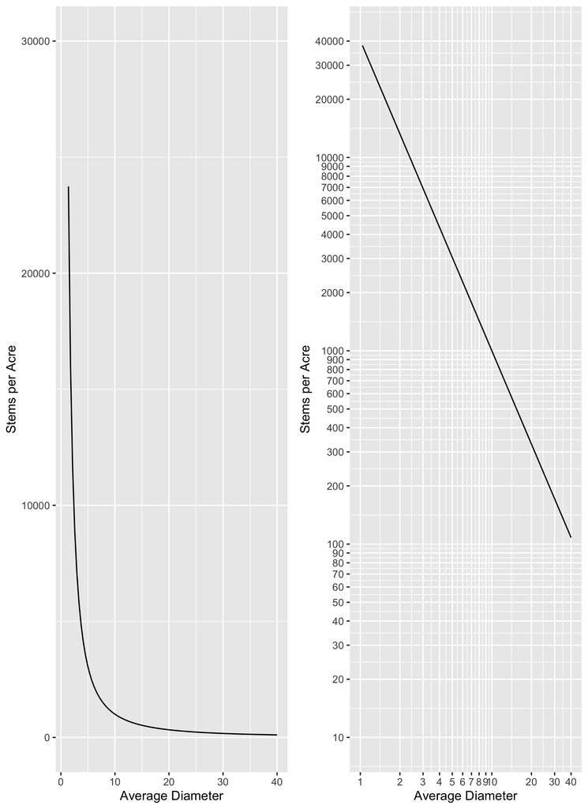

# Different species

In `forester::Reineke_1933`, you can find some of the original data of the average diameter *Inches* for different number of stems *per Acre* which was included in Reineke’s graphs, particularly for two species: White fir, *Abies concolor* and Red fir, *Abies magnifica*.

Reineke’s White and Red Fir stands

| AverageDiameterInches | NperAcre | SPP |
| --- | --- | --- |
| 1.987748 | 9048.946 | Abies magnifica |
| 2.592144 | 7173.244 | Abies magnifica |
| 2.553771 | 6818.134 | Abies magnifica |
| 3.401207 | 6267.346 | Abies magnifica |
| 3.345092 | 5170.098 | Abies magnifica |
| 2.941162 | 4429.808 | Abies magnifica |

| AverageDiameterInches | NperAcre | SPP |
| --- | --- | --- |
| 5.872452 | 1336.207 | Abies concolor |
| 6.209701 | 1287.062 | Abies concolor |
| 6.271728 | 1357.560 | Abies concolor |
| 8.079158 | 1235.057 | Abies concolor |
| 7.461208 | 896.852 | Abies concolor |
| 7.642091 | 846.951 | Abies concolor |

Let’s fit a regression to the number of stems per Acre versus mean diameter in Inches.

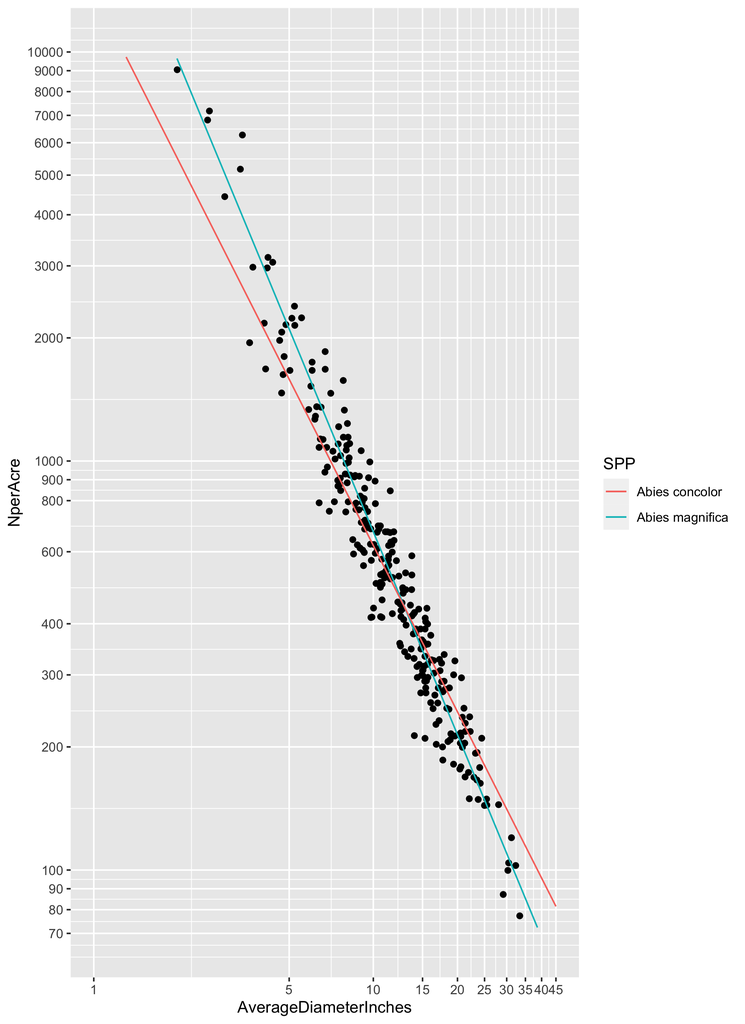

```r
Reineke_all <- Reineke_1933 %>% mutate(SPP="All")
Reineke_1933 <- rbind(Reineke_1933,Reineke_all)

model1<- Reineke_1933 %>%
  group_by(SPP) %>%
  nest() %>%
  mutate(Model= map(data, ~nls(NperAcre~ a * AverageDiameterInches^(b),start=list(a=-1,b=2),data=.))) %>%
# extract formula from each model, convert to one-sided form, &
# replace coefficients with fitted values, & store in dataframe
# as character string
rowwise() %>%
  mutate(func = formula(Model) %>%
           as.character() %>%
           magrittr::extract(3) %>%
           gsub("AverageDiameterInches", ".x", ., fixed = T) %>%
           gsub("a", Model$m$getPars()[1], .) %>%
           gsub("b", Model$m$getPars()[2], .) %>%
           paste("~", ., collapse = "")) %>%
  ungroup()
```

When you draw the curve to reflect the maximum residuals rather than the mean residuals, it will reflect the maximum possible densities for a species. Usually the slope is close to -1.605.

$$log_{10}(N) = -1.605 * log_{10}(\bar{D}) + k$$

Reineke calls the line that passes through *1’000 trees per Acre at 10 inches diameter* the **“Reference curve”**. It’s also called the self-thinning line or the maximum-density line (Wikipedia).

The *Reference curve* has a quite similar slope between species, and can be adjusted using the constant $ k $.

Let’s calculate $ k $ for the *Reference curve* for the slope -1.605.

$$log_{10}(1000) = -1.605*log_{10}(10)+ k$$

This is the same as:

$$3 = -1.605 * 1 + k = -1.605 + k$$
Therefore,
$$k = 3 + 1.605 = 4.605$$
Since we know that $ k = log_{10}(a) $

The self-thinning line which crosses 1000 stems at an average diameter of 10 inches is then written:

$$N = 1000 = 10^{4.605}*\bar{D}^{-1.605}$$

and on a log-log scale, this becomes:

$$log_{10}(N)= log_{10}(1'000) = 3 = -1.605*log_{10}(\bar{D}) + 4.605$$

This means that $ a $ of any number of stems per acre at an average diameter of 10 inches can be described:
$$log_{10}(SDI) = -1.605*(1) + k$$

## Stand Density Index

At the same slope as the reference curve, other, parallell curves can be drawn with different numbers of stems per acre at 10 inches diameter, i.e.
$$log(N) = -1.605 * log(10) + k$$

When the average diameter is 10 inches, i.e. $ log_{10}(10) = 1 $, Our coefficient $ a $ in $ N = ax^{b} $ becomes $ 10^k $, where $ k = log(N)+1.605 $

Aa curve for SDI=900 is then drawn:
$$log_{10}(900) = -1.605 * log_{10}(10) + k$$
Where $ k $ is
$$k = log_{10}(900)+1.605$$

Create one function for each SDI between 1000 and 100 with an increment of -100.

```r
SDI_func <- function(SDI){
  as.formula(paste("~",(10^(1.605+log10(SDI))), "*.x^(-1.605)"))
}

SDIlist <- data.frame(SDI=seq(from=1000, to=100,by=-100))

SDIlist <- SDIlist %>%
  mutate(func= map(SDI,SDI_func))

SDIlist <- SDIlist %>%
  mutate(xcordlab=40)

SDIlist <- SDIlist %>% rowwise() %>% mutate(ycordlab= map(.x=xcordlab,.f=func)) %>% unnest(ycordlab)

SDIlist$linetype <- c(1,rep(2,nrow(SDIlist)-1))

SDIlist$SDI <- factor(SDIlist$SDI, levels=c("1000","900","800","700","600","500","400","300","200","100"))
SDIlist$linetype <- factor(SDIlist$linetype, levels=c(1,2))
print(SDIlist)
```

```
#> # A tibble: 10 x 5
#>    SDI   func      xcordlab ycordlab linetype
#>    <fct> <list>       <dbl>    <dbl> <fct>
#>  1 1000  <formula>       40    108.  1
#>  2 900   <formula>       40     97.3 2
#>  3 800   <formula>       40     86.5 2
#>  4 700   <formula>       40     75.6 2
#>  5 600   <formula>       40     64.8 2
#>  6 500   <formula>       40     54.0 2
#>  7 400   <formula>       40     43.2 2
#>  8 300   <formula>       40     32.4 2
#>  9 200   <formula>       40     21.6 2
#> 10 100   <formula>       40     10.8 2
```

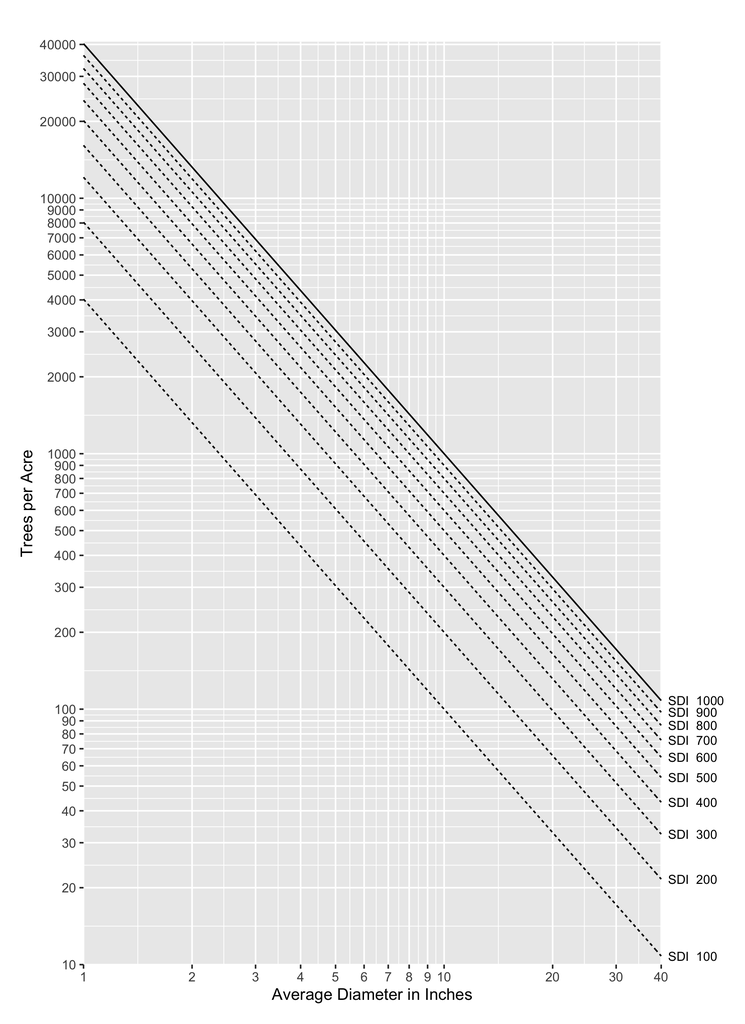

```r
ggplot()+
  scale_x_continuous(limits = c(1,40),breaks=c(1,2,3,4,5,6,7,8,9,10,20,30,40),trans=log_trans())+
  scale_y_continuous(limits=c(10,41000),breaks = c(10,20,30,40,50,60,70,80,90,100,200,300,400,500,600,700,800,900,1000,2000,3000,4000,5000,6000,7000,8000,9000,10000,20000,30000,40000),trans=log_trans())+
  lapply(seq(1,nrow(SDIlist)),
         function(i) geom_function(fun = SDIlist$func[[i]],
                                   aes(linetype=SDIlist$linetype[i])))+
  lapply(seq(1,nrow(SDIlist)),
         function(i) annotate("text",
                              label=paste("  SDI ",SDIlist$SDI[i]),
                              x=SDIlist$xcordlab[i],
                              y=SDIlist$ycordlab[i],
                              hjust=0,
                              size=3))+
  theme(legend.position = "none")+
  coord_cartesian(expand = FALSE,clip="off",xlim = c(1,40))+
  theme(plot.margin=unit(c(1,2,0.5,0.5),"cm"))+
  xlab("Average Diameter in Inches")+
  ylab("Trees per Acre")
```